← Volver a la página principal

# TALLER DE INTEGRACIÓN I:

## **Introducción**

### **Metodologías ágiles: SCRUM**

La metodología Scrum permite abordar proyectos complejos desarrollados en entornos dinámicos y cambiantes de un modo flexible. Está basada en entregas parciales y regulares del producto final en base al valor que ofrecen a los clientes. Dicho en otras palabras: Scrum sirve para mejorar el trabajo colaborativo entre equipos.

**Sprints**

- **¿Qué son los sprints?:** Un sprint es un período breve de tiempo fijo en el que un equipo de scrum trabaja para completar una cantidad de trabajo establecida. Los sprints se encuentran en el corazón de las metodologías scrum y ágil, y hacer bien los sprints ayudará a tu equipo ágil a lanzar mejor software con menos quebraderos de cabeza.
- **¿Qué es la planificación de sprints?:** Tienes que decidir cuánto tiempo va a durar, el objetivo del sprint y por dónde vas a empezar. La sesión de planificación de sprints inicia el sprint definiendo el orden del día y el punto de atención. Si se hace correctamente, también crea un entorno en el que el equipo está motivado, se siente retado y puede triunfar. Las malas planificaciones de sprints pueden fastidiar al equipo al definir expectativas no realistas.
  - El qué
  - El cómo
  - El quién
  - Los elementos de trabajo
  - El resultado
- **Planificación de sprints**: Cuando se practica el scrum, la reunión de planificación del sprint se celebra al principio del sprint y, en ella, los equipos identifican lo que se puede ofrecer en el sprint y cómo se va a llevar a cabo el trabajo. Al final de la reunión de planificación, cada miembro del scrum debe tener claro qué se puede entregar en el sprint y cómo se puede entregar el incremento.
  - Reunión rápida diaria: una reunión diaria corta de 15 minutos (o menos) para analizar el progreso e identificar impedimentos. Se ruega a los asistentes a participar de pie para que la reunión sea breve.
    - Asistentes: equipo de desarrollo, experto en scrum y propietario del producto.
    - Cuándo: Una vez al día, normalmente por la mañana.
    - Duración: no más de 15 minutos. No reserves una sala de conferencias ni celebres la reunión sentados. ¡Estar de pie hace que la reunión dure menos!
    - Marco ágil: scrum y kanban.
    - Objetivo: las reuniones rápidas diarias están pensadas para informar a todo el mundo en poco tiempo de lo que sucede en el equipo. No se trata de reuniones de estado en detalle. El tono debe ser ligero y divertido, pero informativo. Pide a los miembros del equipo que respondan las preguntas siguientes:
    - Qué terminé ayer?
    - ¿En qué voy a trabajar hoy?
    - ¿Estoy bloqueado con algo?
- **¿Qué es un backlog del producto?**: El backlog de un producto es una lista de trabajo ordenado por prioridades para el equipo de desarrollo que se obtiene de la hoja de ruta y sus requisitos.

Las revisiones de sprints no son retrospectivas. Una revisión de sprint consiste en demostrar el duro trabajo de todo un equipo: diseñadores, desarrolladores y el propietario del producto.

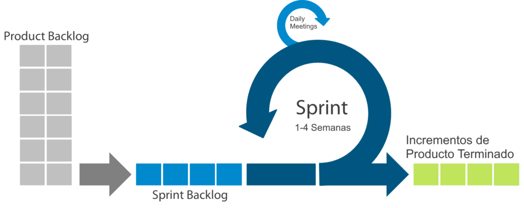

### **Scrum Master**

El Scrum Master tiene dos funciones principales dentro del marco de trabajo: gestionar el proceso Scrum y ayudar a eliminar impedimentos que puedan afectar a la entrega del producto. Además, se encarga de las labores de mentoring y formación, coaching y de facilitar reuniones y eventos si es necesario.

1. **Gestionar el proceso Scrum:** el Scrum Master se encarga de gestionar y asegurar que el proceso Scrum se lleva a cabo correctamente, así como de facilitar la ejecución del proceso y sus mecánicas. Siempre atendiendo a los tres pilares del control empírico de procesos y haciendo que la metodología sea una fuente de generación de valor.
2. **Eliminar impedimentos:** esta función del Scrum Master indica la necesidad de ayudar a eliminar progresiva y constantemente impedimentos que van surgiendo en la organización y que afectan a su capacidad para entregar valor, así como a la integridad de esta metodología. El Scrum Master debe ser el responsable de velar porque Scrum se lleve adelante, transmitiendo sus beneficios a la organización facilitando su implementación.

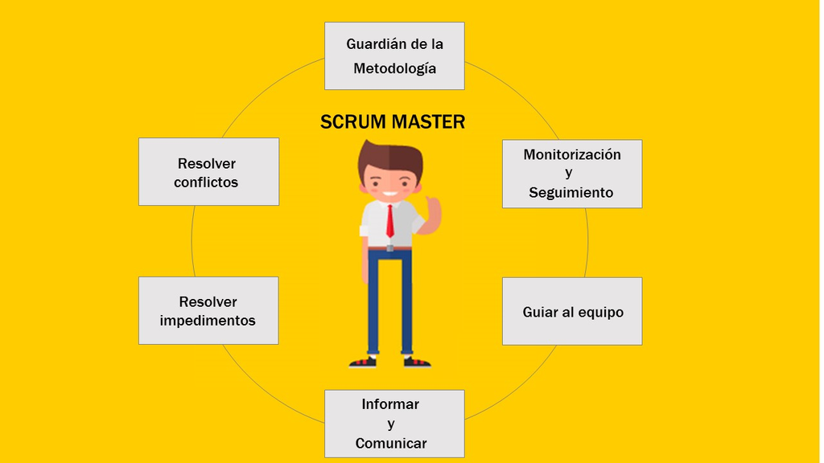

### Backlog del sprint

El backlog del sprint consiste en un subconjunto de elementos de la lista del producto, siendo estas historias de usuario las que se trabajaran y los objetivos que se quieren cumplir, la lista de pendientes del sprint debe estar lo suficientemente detallado para que el equipo sea capaz de comprenderlo.

- Pueden utilizar Trello para darle seguimiento a las actividades.

#### Burn-Down

Para tener más control sobre el backlog se utiliza el gráfico Burn-Down, es un gráfico de trabajo pendiente a lo largo del tiempo, muestra la velocidad a la que se están completando los objetivos. Permite extrapolar si el equipo podrá completar el trabajo en el tiempo estimado. Usualmente el trabajo remanente (backlog) se muestra en el eje vertical y el tiempo en el eje horizontal. Muy útil para realizar adaptaciones entre los sprints

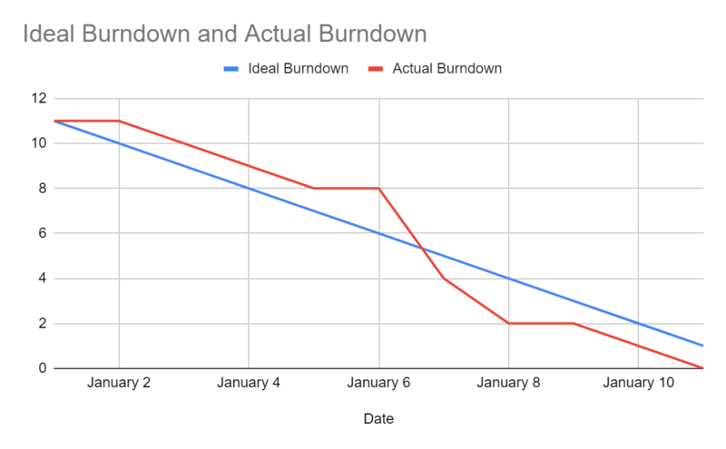

### Retrospectiva

La retrospectiva es una reunión con el cliente, el objetivo es tener una retroalimentación rápida, normalmente se hace en el último día del sprint. Se revisa lo que se ha aprendido y lo que se ha logrado desarrollar.

Si no se logran cumplir los objetivos, tenemos que ser siempre transparentes y tratar de resolverlo para el siguiente sprint. Es una reunión informal y abierta al diálogo, no es una reunión de seguimiento.

El Scrum Master es responsable de programar la reunión, al final de la reunión vamos a tener una lista de producto actualizada.

Después del sprint review viene una retrospectiva, donde el equipo de scrum analiza las oportunidades de mejora, no buscamos culpables, buscar de forma positiva como se puede mejorar.

Retrospectiva: Herramientas, tenemos todo lo necesario para cumplir nuestro objetivo

- Relaciones, son fluidas o hay problemas
- Personas, como es la interacción
- Procesos, todavía se ajustan al desarrollo

Preguntarse:

- ¿Qué hicimos bien?
- ¿Qué hicimos mal?
- ¿Qué podemos mejorar?

## Perfil de proyecto

1. Completar guía de sistematización de proyectos
2. Backlog completamente detallado.
3. Crear proyecto (scrum master) en github
4. Entregar diagramas de: * Arquitectura de software * Diagrama de secuencia * Modelo entidad-relación * Diagrama de componentes